# Fitting the SEIR model to the Portuguese data

Tiago dos Santos

3/17/2020

```r
source("simulation_seir_model.R") #simulation_seir_model function
```

The goal of this document is to estimate the real number of infections in portugal (not the confirmed cases of infection) usign the number of deaths and other parameters, like: - Death Rate - $R_0$ - Infection Rate - Transmission rate - Variation over time of the $R$ as a side effect of Public Health Measures

# Estimating the number of infeccious individuals given the number of deaths

It can be said that if the death rate is (for example) 5%, and: - If the time between exposition onset (the day in which the person got the virus, but it is still not infected) and the individual to became infeccious is 5 days - If from that point on, for a death to occur it takes 15 days - We know that at a given day, there was 1 death

In this setup, we can extrapolate that 20 days before the death, there was 20 infected - from which 1 individual died 20 days after. Now, in that day 20 days ago, the individuals are not aware that they are infected - because no symptoms are shown.

To continue the simulation, let’s estimate the $R_0$ with the current confirmed cases in portugal

## Estimating the $R_0$ with confirmed cases

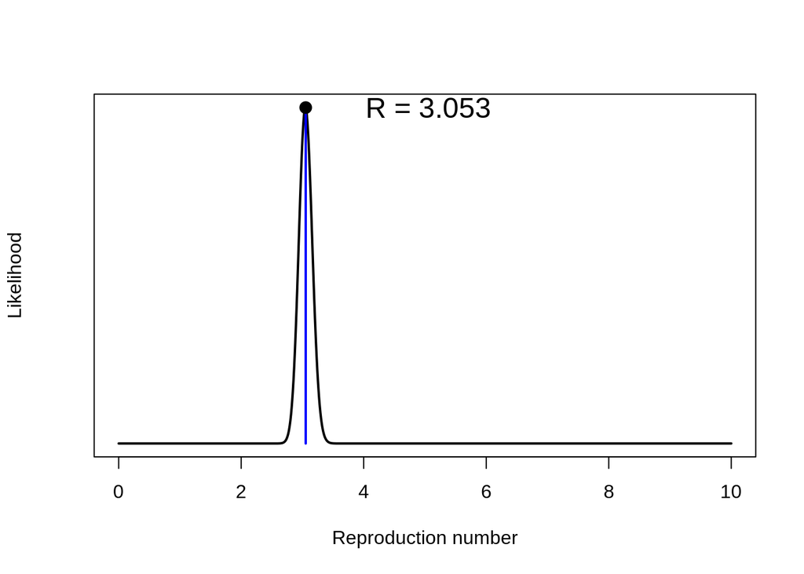

```r
source("simulation_seir_model.R")
library(incidence)
library(earlyR)

incidences <- c()
incidences <- c(incidences, rep("2020-3-2", 2))
incidences <- c(incidences, rep("2020-3-3", 0))
incidences <- c(incidences, rep("2020-3-4", 3))
incidences <- c(incidences, rep("2020-3-5", 3))
incidences <- c(incidences, rep("2020-3-6", 5))
incidences <- c(incidences, rep("2020-3-7", 7))
incidences <- c(incidences, rep("2020-3-8", 10))
incidences <- c(incidences, rep("2020-3-9", 0))
incidences <- c(incidences, rep("2020-3-10", 11))
incidences <- c(incidences, rep("2020-3-11", 18))
incidences <- c(incidences, rep("2020-3-12", 0))
incidences <- c(incidences, rep("2020-3-13", 53))
incidences <- c(incidences, rep("2020-3-14", 57))
incidences <- c(incidences, rep("2020-3-15", 76))
incidences <- c(incidences, rep("2020-3-16", 86))
incidences <- c(incidences, rep("2020-3-17", 117))
incidences <- c(incidences, rep("2020-3-18", 194))
incidences <- c(incidences, rep("2020-3-18", 143))

today <- as.Date("2020-03-18")
incidence_obj <- incidence(as.Date(incidences), last_date = today)
sars_cov_2_si_mu <- 6.5 # mean days for a person to be infectious and with simptoms
sars_cov_2_si_sigma <- 4 # standard deviation in days
base_R_stats <- get_R(incidence_obj, si_mean = sars_cov_2_si_mu, si_sd = sars_cov_2_si_sigma)

plot(base_R_stats)
```

```r
library(plotly)

changes_over_time = list("20" = 1.5, "25" = 1.2, "30" = 1., "35" = 0.7)
changes_over_time_labels = c("Moderate Isolation Measures")

number_of_deaths = 2

initial_infectious_individuals = 95/5*number_of_deaths

sim_data = simulation_seir_model(
  initial_susceptible_individuals = 10283822, #Portuguese Population, https://www.pordata.pt/Portugal/Popula%C3%A7%C3%A3o+residente++m%C3%A9dia+anual+total+e+por+grupo+et%C3%A1rio-10
  initial_infectious_individuals = initial_infectious_individuals,
  initial_exposed_individuals = 20*initial_infectious_individuals,
  initial_recovered_individuals = 0,
  initial_death_individuals = 0,
  start_date = "2020-03-01",
  amount_of_days = 30*4,
  initial_r0 = base_R_stats$R_ml,
  infection_rate = 1/sars_cov_2_si_mu,
  days_with_new_r0 = changes_over_time
)

plotly::plot_ly(sim_data, x = ~days) %>%
  plotly::add_lines(y = ~(infectious_individuals + recovered_individuals + dead_individuals)*0.75, name = "Confirmed Accumulated", line = list(color = "gray")) %>%
  plotly::add_lines(y = ~infectious_individuals + recovered_individuals + dead_individuals, name = "Infected Accumulated", line = list(color = "black")) %>%
  plotly::add_lines(y = ~exposed_individuals, name = "Exposed", line = list(color = "blue")) %>%
  plotly::add_lines(y = ~infectious_individuals, name="Infectious",line = list(color = "orange")) %>%
  plotly::add_lines(y = ~recovered_individuals, name="Recovered Accumulated",line = list(color = "green")) %>%
  plotly::add_lines(y = ~dead_individuals, name="Death Accumulated",line = list(color = "red"))
```

[interactive chart not shown]